# Retweet Networks

## Concepts

### Retweets

On Twitter a user can retweet the tweets posted by other users. By doing this, the user **creates another tweet with the exact same content as the original, with an additional attribution to the original tweet**. This way, the information about the original author of the tweet is preserved.

Note that the **original tweet is always attributed in a retweet**, eliminating the possibility of retweeting a retweet. When a user retweets a tweet, it is distributed to all her/his followers, just as if it were an originally authored tweet.

Users retweet content that they find interesting or agreeable. Retweets have been analyzed in the context of information spreading and cascade formation. Additionally, retweets have been analyzed as a form of influence.

### Communities

A community can be defined as a group of users that interact with each other more frequently than with those outside the group and are more similar to each other than to those outside the group.

### Degree centrality

Degree centrality is a measure of influence in the network. In degree centrality measure the number of incoming links on a directed graph. In the context of retweets, a high in degree centrality means that a user is retweeting a lot.

## Analysis

### Load required libraries

```r
library(twitteR)
library(igraph)
library(dplyr)
```

### Setup keys

Here I am retrieving the keys from an environmental file, on : ~/.Renviron

https://csgillespie.github.io/efficientR/3-3-r-startup.html#renviron

```r
api_key <- Sys.getenv("api_key")
api_secret <- Sys.getenv("api_secret")
access_token <- Sys.getenv("access_token")
access_token_secret <- Sys.getenv("access_token_secret")
```

### Setup connection

```r
setup_twitter_oauth(api_key, api_secret, access_token, access_token_secret)
```

```
[1] "Using direct authentication"
```

### Search for a keyword in real-time

Depending on your choice of keywords, this may take a while.

https://www.rdocumentation.org/packages/twitteR/versions/1.1.9/topics/searchTwitter

```r
alltweets <- searchTwitter("brexitvote", n = 1500)
alltweets <- twListToDF(alltweets)
tweets <- alltweets[1:500,]
```

### Split data frame

Split tweets into two sets: the original tweets and the **retweets**.

In this example we are only interested in the retweet network.

```r
split_point = split(tweets, tweets$isRetweet)
```

### Create graph

Create new variable with the retweet sender.

```r
reTweets = mutate(split_point[['TRUE']], sender = substr(text, 5, regexpr(':', text) - 1))
```

Create edge list of the retweet network.

```r
edge_list = as.data.frame(cbind(sender = tolower(reTweets$sender), receiver = tolower(reTweets$screenName)))
```

Add weight to the edges, based on the frequency.

```r
edge_list = count(edge_list, sender, receiver)
```

Construct a directed graph from the edge list.

```r
reTweets_graph <- graph_from_data_frame(d=edge_list, directed=T)
```

### Plot graph

Plot retweet network.

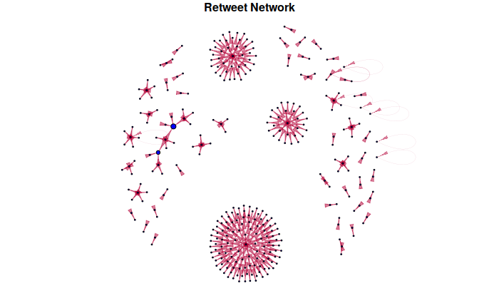

```r
par(bg="white", mar=c(1,1,1,1))
plot(reTweets_graph,
     vertex.color="blue",
     vertex.size=(degree(reTweets_graph, mode = "in")), #sized by in-degree centrality
     vertex.label = NA,
     edge.arrow.size=0.8,
     edge.arrow.width=0.5,
     edge.width=edge_attr(reTweets_graph)$n/10, #sized by edge weight
     edge.color=hsv(h=.95, s=1, v=.7, alpha=0.5))
title("Retweet Network", cex.main=1, col.main="black")
```

Force layouts are a class of algorithms for drawing graphs in an aesthetically-pleasing way. They consider a force between any two nodes and determines which direction a node should move based on the sum of the force vectors.

Plot graph using a force layout.

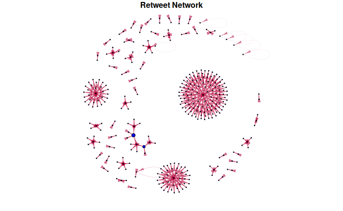

```r
par(bg="white", mar=c(1,1,1,1))
plot(reTweets_graph, layout=layout.fruchterman.reingold,
     vertex.color="blue",
     vertex.size=(degree(reTweets_graph, mode = "in")), #sized by in-degree centrality
     vertex.label = NA,
     edge.arrow.size=0.8,
     edge.arrow.width=0.5,
     edge.width=edge_attr(reTweets_graph)$n/10, #sized by edge weight
     edge.color=hsv(h=.95, s=1, v=.7, alpha=0.5))
title("Retweet Network", cex.main=1, col.main="black")
```

**A note about large networks:**

General force algorithms can be slow for large networks.

Force Atlas 2 attempts to resolve the shortcomings of the Force algorithm by making a balance between the quality of the final layout and the speed of the computation algorithm.

https://github.com/analyxcompany/ForceAtlas2